# final_project__slide_last slides

## Analyzing Ford GoBike System Data

> - ### By Wael Alharbi

## Introduction :

> Ford GoBike is the Bay Area's new bike share system, with thousands of public bikes for use across San Francisco, East Bay and San Jose. Renting Bikes is designed with convenience in mind. it’s a fun and affordable way to get around town.It aslo offers Single Ride is 2 dollars per day which is great for one way trip, Monthly Memberships is 15 dollars per month for its good deal for locals and Access Pass for 10 dollars which is perfect for exploring.

## Distribution of trip over day hours

> the system is used increasingly in two shifts, the first from 7 to 9 in the morning and back down, the second period between 4 pm to 6 pm.

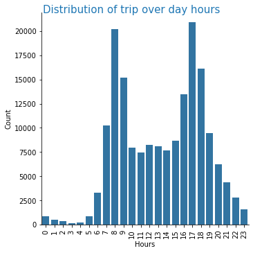

```python
u = sns.catplot(data=df, x='start_time_hour', kind='count', color=base_color )
u.set_axis_labels("Hours", "Count")
u.fig.suptitle('Distribution of trip over day hours', fontsize=15, color=base_color , y =1);
plt.xticks(rotation=90);
```

## Distribution of trips per minute

> > It looks most of the trips were less than half an hour long with most of them fell between 5 to 10 minutes range.

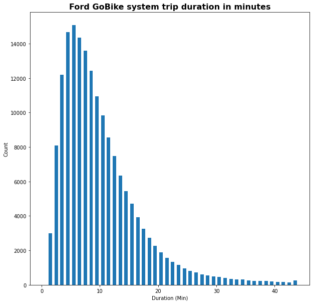

```python
plt.figure(figsize = [10, 10])
bin_edges = np.arange(0, 45, 1)
plt.hist(data = df, x = 'duration_min', bins = bin_edges, rwidth = 0.6);
plt.title("Ford GoBike system trip duration in minutes", fontsize=16, fontweight='bold')
plt.xlabel('Duration (Min)')
plt.ylabel('Count');
```

## Distribution of daily trips based on gender

> The graph above shows ,the number of rides per day, and we can see the weekend it is has the lowest number of rides for both male and female.

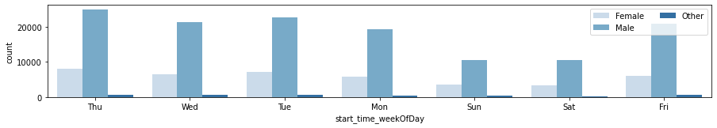

```python
plt.figure(figsize = [15, 15]);
ax = plt.subplot(6, 1, 2);
sns.countplot(data = df, x = 'start_time_weekOfDay', hue = 'member_gender', palette = 'Blues');
ax.legend(ncol = 2);
```

## Age distribution based on the type of user

> As shown in the chart above , Most of the customers type is "subscriber" , They are from the age group of 31-40 years.

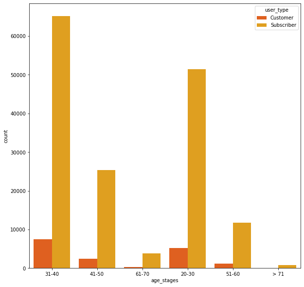

```python
plt.figure(figsize = [10, 10]);
sns.countplot(data = df, x = 'age_stages', hue = 'user_type', palette = 'autumn' );
```

## The Daily Usage of Bike Rides per User Type Based on Gender

> Trips are go down for both male and female subscribers at the weekend, And customers maintain more than 1,500 rides per day almost every day and there is no high drop on the weekend.

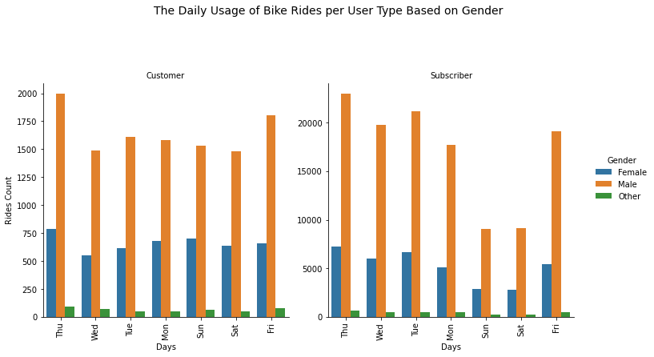

```python
plt.figure(figsize = [15, 15]);
u = sns.catplot(data=df, x='start_time_weekOfDay', col="user_type", aspect=20/20,hue='member_gender', kind='count',sharey=False)

u.set_axis_labels('Days', 'Rides Count')
u.set_xticklabels(rotation=90)
u._legend.set_title('Gender')
u.set_titles('{col_name}');
u.fig.suptitle('The Daily Usage of Bike Rides per User Type Based on Gender', fontsize=14, y=1.2);
```

## Trip Duration In minutes for Each User Type Based on Gender

> - As shown in the chart above it is show the duration for each user type based on gender.
> - Customer users have higher duration than subscriber users.

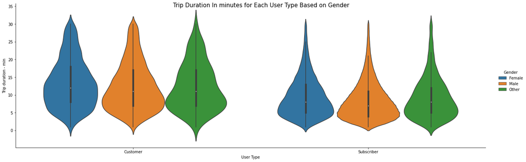

```python
ax = sns.catplot(data=df.query("duration_min <= 30"), x='user_type', y="duration_min", hue="member_gender", kind="violin", height=6, aspect=3)
ax.set_axis_labels("User Type", "Trip duration - min")
ax._legend.set_title('Gender')
ax.fig.suptitle('Trip Duration In minutes for Each User Type Based on Gender', fontsize=15);
```